# reproducible_research_project_1

Juan Osobampo

16/12/2020

```r
knitr::opts_chunk$set(echo = TRUE)
library(ggplot2)
library(gridExtra)
library(dplyr)
zipUrl <-"https://d396qusza40orc.cloudfront.net/repdata%2Fdata%2Factivity.zip"
zipFile <- "repdata_data_activity.zip"

if (!file.exists(zipFile)) {
  download.file(zipUrl, zipFile, mode = "wb")
}

# unzip zip file containing data if data directory doesn't already exist
dataPath <- "activity.csv"
if (!file.exists(dataPath)) {
  unzip(zipFile)
}
activity <- read.csv("activity.csv")
head(activity)
```

```
##   steps       date interval
## 1    NA 2012-10-01        0
## 2    NA 2012-10-01        5
## 3    NA 2012-10-01       10
## 4    NA 2012-10-01       15
## 5    NA 2012-10-01       20
## 6    NA 2012-10-01       25
```

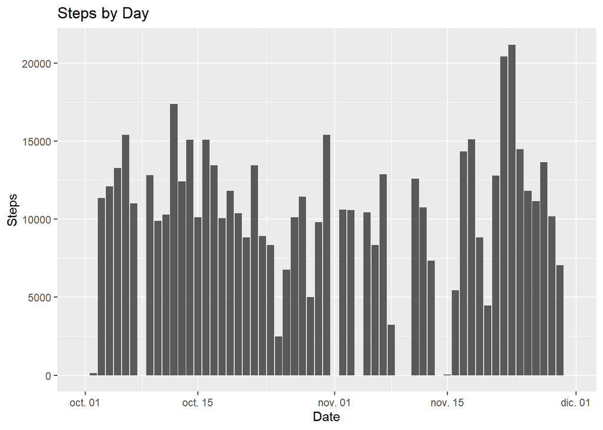

```r
#Turn the column into date class
activity$date <- as.Date(activity$date, tryFormats = c("%Y-%m-%d"))
#Creating histogram
ag_act <- aggregate(activity$steps , by= list(activity$date), FUN = sum)

#Replace NA's in the DF to 0
ag_act2<- ag_act
ag_act2[is.na(ag_act2)] <- 0

plot1 <- ggplot(ag_act2, aes(Group.1, x)) + geom_histogram(stat='identity')+ xlab("Date") + ylab("Steps")+ ggtitle("Steps by Day")
plot1
```

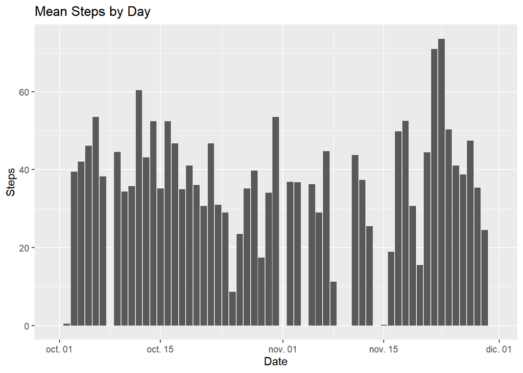

```r
#As there are  NA values in activity df, we change those to 0 to get means
activity2<- activity
activity2[is.na(activity2)] <- 0
p3 <- aggregate(activity2$steps , by= list(activity2$date), FUN = mean)
ps3 <- ggplot(p3, aes(Group.1, x)) + geom_histogram(stat='identity')+ xlab("Date") + ylab("Steps")+ ggtitle("Mean Steps by Day")
ps3
```

```r
#Median of steps recorded by day
median_and_mean_steps <- summary(p3$x)
median_and_mean_steps
```

```
##    Min. 1st Qu.  Median    Mean 3rd Qu.    Max.
##    0.00   23.53   36.09   32.48   44.48   73.59
```

#### As for the step 4 instruction, we are plotting the mean number of steps by day

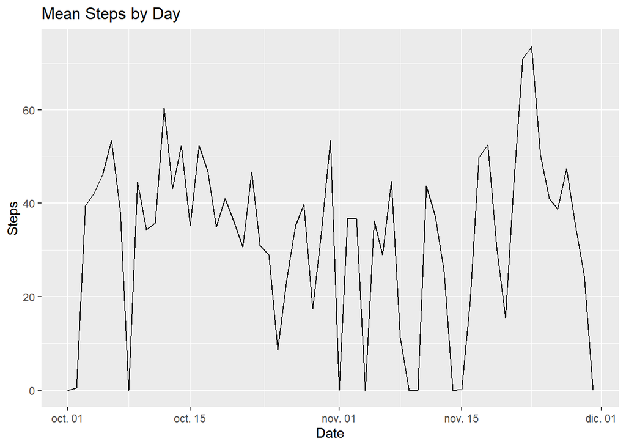

```r
ps3 <- ggplot(p3, aes(Group.1, x)) + geom_line(stat='identity')+ xlab("Date") + ylab("Steps")+ ggtitle("Mean Steps by Day")
ps3
```

```r
median_and_mean_steps_ps3 <- summary(ps3)
```

[output not shown]

#### For the step 5, we must get the most steps possible in a 5-min interval

```r
days <- as.data.frame( weekdays(as.Date(activity2$date)))
ag_act3 <- as.data.frame(bind_cols( activity2, days))
max_steps <- max(activity2$steps)
match(max_steps, table= activity2$steps)
```

```
## [1] 16492
```

```r
activity2[16492,]
```

```
##       steps       date interval
## 16492   806 2012-11-27      615
```

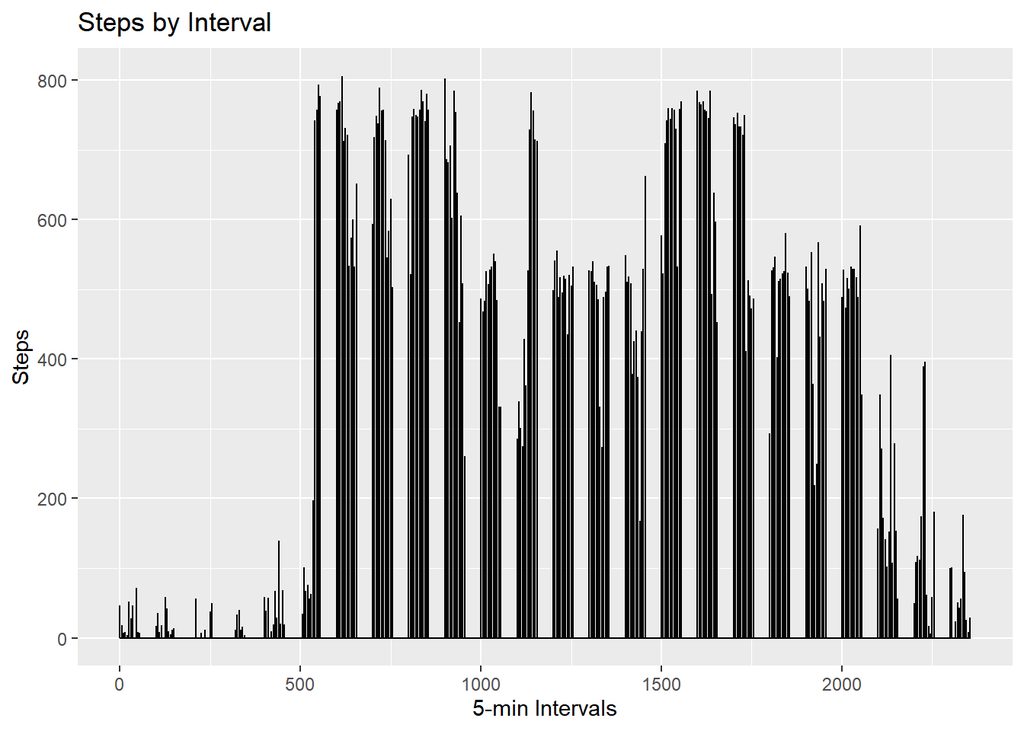

```r
plot_step5 <- ggplot(ag_act3, aes(interval, steps)) + geom_line(stat='identity')+ xlab("5-min Intervals") + ylab("Steps")+ ggtitle("Steps by Interval")
plot_step5
```

#### For the step 6, we are asked for an strategy to work with NA’s in the data frame, an option is to turn them into 0

-6.1. To work with the data frame, we change de date column into Date class

```r
 #Turn the column into date class
activity$date <- as.Date(activity$date, tryFormats = c("%Y-%m-%d"))
```

-6.2. To avoid multiple same-day data, we use aggregate

```r
#Creating histogram
ag_act <- aggregate(activity$steps , by= list(activity$date), FUN = sum)
```

-6.3. Finally, we count the amount of NA, then change’em to 0 and store them into ag_act2

```r
# Count na
NA_number <- colSums(is.na(ag_act))
NA_number
```

```
## Group.1       x
##       0       8
```

```r
# There are 8 NA
 #Replace NA's in the DF to 0
ag_act2<- ag_act
ag_act2[is.na(ag_act2)] <- 0
```

### For the step 7, we include the NA(now 0) and plot it

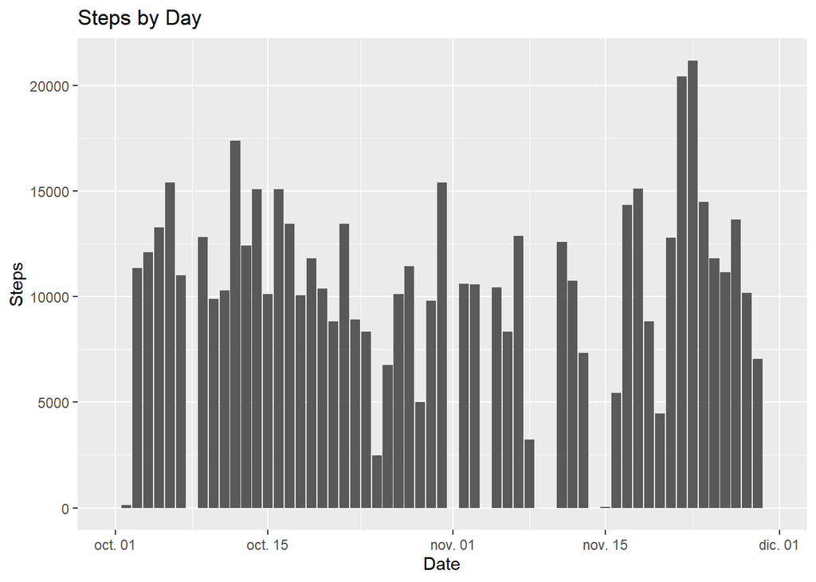

```r
plot1 <- ggplot(ag_act2, aes(Group.1, x)) + geom_histogram(stat='identity')+ xlab("Date") + ylab("Steps")+ ggtitle("Steps by Day")
plot1
```

###A dataset identical to the original is now stored un ag_act3 , being the main difference that NAs are now 0, in addition, there are the names of the day next to the dates

```r
ag_act3
```

[output not shown]

[output cut: 237 more lines]

```r
summary(ag_act3)
```

```
##      steps             date               interval
##  Min.   :  0.00   Min.   :2012-10-01   Min.   :   0.0
##  1st Qu.:  0.00   1st Qu.:2012-10-16   1st Qu.: 588.8
##  Median :  0.00   Median :2012-10-31   Median :1177.5
##  Mean   : 32.48   Mean   :2012-10-31   Mean   :1177.5
##  3rd Qu.:  0.00   3rd Qu.:2012-11-15   3rd Qu.:1766.2
##  Max.   :806.00   Max.   :2012-11-30   Max.   :2355.0
##  weekdays(as.Date(activity2$date))
##  Length:17568
##  Class :character
##  Mode  :character
##
##
##
```

### For the step 8 we must find the name of the day that corresponds the date, then we subset by the day of the week to plot the steps by 5-min intervals, to display all 7 plot we use the require(gridExtra) function

[figure not shown]

```r
monday <- subset.data.frame(ag_act3, ag_act3$`weekdays(as.Date(activity2$date))` == "lunes", select = c(steps, interval))
tuesday <- subset.data.frame(ag_act3, ag_act3$`weekdays(as.Date(activity2$date))` == "martes", select = c(steps, interval))
wednesday <- subset.data.frame(ag_act3, ag_act3$`weekdays(as.Date(activity2$date))` == "miércoles", select = c(steps, interval))
thursday <- subset.data.frame(ag_act3, ag_act3$`weekdays(as.Date(activity2$date))` == "jueves", select = c(steps, interval))
friday <- subset.data.frame(ag_act3, ag_act3$`weekdays(as.Date(activity2$date))` == "viernes", select = c(steps, interval))
saturday <- subset.data.frame(ag_act3, ag_act3$`weekdays(as.Date(activity2$date))` == "sábado", select = c(steps, interval))
sunday <- subset.data.frame(ag_act3, ag_act3$`weekdays(as.Date(activity2$date))` == "domingo", select = c(steps, interval))
require(gridExtra)
ps8.1 <- ggplot(monday, aes(interval, steps)) + geom_line(stat='identity')+ xlab("Monday 5-min Intervals") + ylab("Steps")+ ggtitle("Monday Steps by Interval")
ps8.2 <- ggplot(tuesday, aes(interval, steps)) + geom_line(stat='identity')+ xlab("Tuesday 5-min Intervals") + ylab("Steps")+ ggtitle("Tuesday Steps by Interval")
ps8.3 <- ggplot(wednesday, aes(interval, steps)) + geom_line(stat='identity')+ xlab("Wednesday 5-min Intervals") + ylab("Steps")+ ggtitle("Wednesday Steps by Interval")
ps8.4 <- ggplot(thursday, aes(interval, steps)) + geom_line(stat='identity')+ xlab("Thursday 5-min Intervals") + ylab("Steps")+ ggtitle("Thursday Steps by Interval")
ps8.5 <- ggplot(friday, aes(interval, steps)) + geom_line(stat='identity')+ xlab("Friday 5-min Intervals") + ylab("Steps")+ ggtitle("Friday Steps by Interval")
ps8.6 <- ggplot(saturday, aes(interval, steps)) + geom_line(stat='identity')+ xlab("Saturday 5-min Intervals") + ylab("Steps")+ ggtitle("Saturday Steps by Interval")
ps8.7 <- ggplot(sunday, aes(interval, steps)) + geom_line(stat='identity' )+ xlab("Sunday 5-min Intervals") + ylab("Steps")+ ggtitle("Sunday Steps by Interval")
require(gridExtra)
grid.arrange(ps8.1, ps8.2, ps8.3, ps8.4, ps8.5, ps8.6, ps8.7, ncol=7)
```